# User Guide: 2 Autoplot Methods

‘ggspectra’ 0.3.17

Pedro J. Aphalo

2025-09-24

## Introduction

Package `ggspectra` extends `ggplot2` with stats, geoms and annotations suitable for light and radiation spectra. It also defines `ggplot()` and `autoplot()` methods specialized for the classes defined in package `photobiology` for storing different types of spectral data. This vignette describes the use of these `autoplot()` methods.

```r
library(ggplot2)
library(photobiologyWavebands)
library(ggspectra)
library(ggrepel)

# ensure all labels are plotted
options(ggrepel.max.overlaps = Inf)
```

We will use an individual sunlight spectrum `sun.spct` and a short time series of spectra `sun_evening.spct` and `sun_evening.mspct’, from ‘photobiology’ for examples.

```r
summary(sun.spct)
```

```
## Summary of source_spct [522 x 3] object: sun.spct
## Wavelength range 280-800 nm, step 0.9230769-1 nm
## Label:  sunlight, simulated
## Measured on  2010-06-22 09:51:00  UTC
## Measured at 60.20911 N, 24.96474 E; Kumpula, Helsinki, FI
## Variables:
##  w.length: Wavelength [nm]
##  s.e.irrad: Spectral energy irradiance [W m-2 nm-1]
##  s.q.irrad: Spectral photon irradiance [mol s-1 m-2 nm-1]
## --
##     w.length       s.e.irrad        s.q.irrad
##  Min.   :280.0   Min.   :0.0000   Min.   :0.000e+00
##  1st Qu.:409.2   1st Qu.:0.4115   1st Qu.:1.980e-06
##  Median :539.5   Median :0.5799   Median :2.929e-06
##  Mean   :539.5   Mean   :0.5160   Mean   :2.407e-06
##  3rd Qu.:669.8   3rd Qu.:0.6664   3rd Qu.:3.155e-06
##  Max.   :800.0   Max.   :0.8205   Max.   :3.375e-06
```

```r
summary(sun_evening.spct)
```

```
## Summary of source_spct [7,965 x 3] object: sun_evening.spct
## containing  5  spectra in long form
## Wavelength range 290-1000 nm, step 0.34-0.47 nm
## Label:  cosine.hour.9
## time.01 measured on 2023-06-12 18:38:00.379657 UTC
## time.02 measured on 2023-06-12 18:39:00.797266 UTC
## time.03 measured on 2023-06-12 18:40:00.714554 UTC
## time.04 measured on 2023-06-12 18:41:00.768459 UTC
## time.05 measured on 2023-06-12 18:42:00.769065 UTC
## Measured at 60.227 N, 24.018 E; Viikki, Helsinki, FI
## Variables:
##  w.length: Wavelength [nm]
##  s.e.irrad: Spectral energy irradiance [W m-2 nm-1]
## --
##     w.length        s.e.irrad          spct.idx
##  Min.   : 290.0   Min.   :0.00000   time.01:1593
##  1st Qu.: 474.4   1st Qu.:0.02315   time.02:1593
##  Median : 654.8   Median :0.03892   time.03:1593
##  Mean   : 651.6   Mean   :0.03659   time.04:1593
##  3rd Qu.: 830.3   3rd Qu.:0.04888   time.05:1593
##  Max.   :1000.0   Max.   :0.07503
```

```r
summary(sun_evening.mspct)
```

```
## Summary of source_mspct [5 x 1] object: sun_evening.mspct
## # A tibble: 5 × 8
##   spct.idx class  dim   w.length.min w.length.max colnames multiple.wl time.unit
##   <chr>    <chr>  <chr>        <dbl>        <dbl> <list>         <dbl> <Duratio>
## 1 time.01  sourc… [1,5…          290        1000. <chr>              1 1s
## 2 time.02  sourc… [1,5…          290        1000. <chr>              1 1s
## 3 time.03  sourc… [1,5…          290        1000. <chr>              1 1s
## 4 time.04  sourc… [1,5…          290        1000. <chr>              1 1s
## 5 time.05  sourc… [1,5…          290        1000. <chr>              1 1s
```

We change the default theme for ggplots.

```r
theme_set(theme_bw(10))
```

## Using the `autoplot()` methods

### The basics

Here we use the same example `source_spct` object from package ‘photobiology’ used in *User Guide 1* to demonstrate parameters common to all `autoplot()` methods for spectra. Methods for plotting of objects of all the classes defined in package ‘photobiology’, except `solute_spct` are available. Function `spct_classes()` lists these classes.

```r
spct_classes()
```

```
##  [1] "calibration_spct" "raw_spct"         "cps_spct"         "filter_spct"
##  [5] "reflector_spct"   "source_spct"      "object_spct"      "response_spct"
##  [9] "chroma_spct"      "solute_spct"      "generic_spct"
```

The simplest possible call to `autoplot()` needs only one argument, the object to plot.

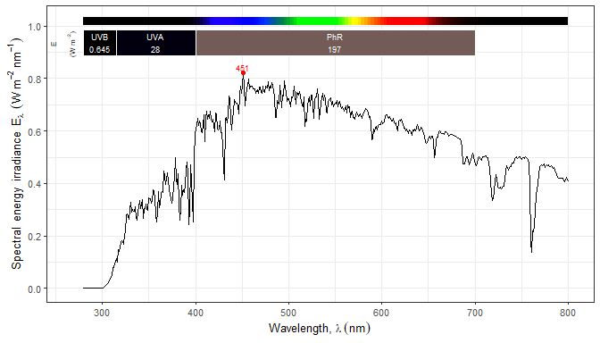

```r
autoplot(sun.spct)
```

In contrast to the examples in the *User Guide 1*, here we obtain directly an annotated plot of the solar spectrum at ground level. This would be of limited use without the possibility to adjust the design and components of the *ggplot* object created. One approach is to use the grammar of graphics to add to the plot. However, it is also possible to control many features of the plot by passing additional arguments in the call to `autoplot()`. User-provided arguments override the defaults.

When plotting `source_spct` and `response_spct` objects we can change the basis of expression of spectral irradiance and spectral response from `"energy"` to `"photon"`. Be aware that by design, within one plot all spectral values and derived summaries will always use the same base of expression.

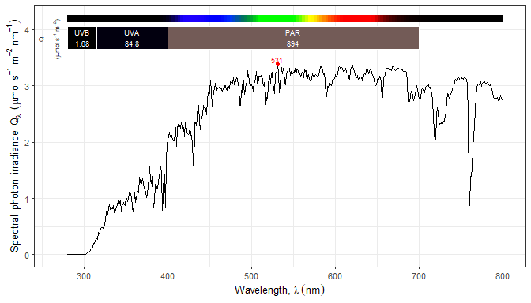

```r
autoplot(sun.spct, unit.out = "photon")
```

We can build and area + line (`"spct"`) plot instead the default line plot.

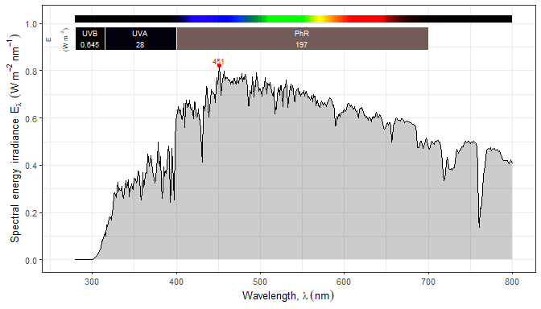

```r
autoplot(sun.spct, geom = "spct")
```

If a single object contains multiple spectra in long form, they are all plotted. In this case no summary values are displayed as they would overlap.

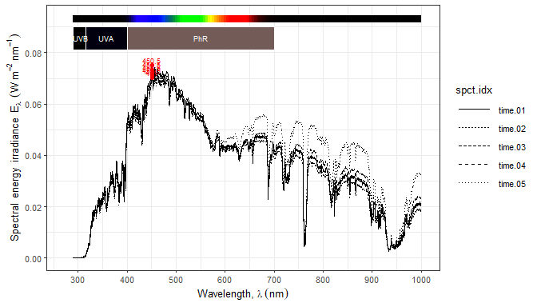

```r
autoplot(sun_evening.spct)
```

In addition to the `autoplot()` methods for individual spectra and spectra in stored long form (`_spct` classes), there are `autoplot()` methods available for collections of spectra (`_mspct` classes). Collections of spectra like `sun_evening.mspct` can be plotted also automatically, as they are combined on-the-fly and plotted as shown above in the example for `sun_evening.spct`.

We use in the examples a simple collection of five spectra. The output and accepted arguments are the same as those in the `autoplot()` methods for multiple spectra in long form described above. The plotting of objects of all the classes for collections of spectra defined in package ‘photobiology’ is similar. However, classes `solute_mspct` and `generic_mspct` are currently not supported. Function `mspct_classes()` lists all the classes for collections of spectra defined in package ‘photobiology’.

```r
mspct_classes()
```

```
##  [1] "calibration_mspct" "raw_mspct"         "cps_mspct"
##  [4] "filter_mspct"      "reflector_mspct"   "source_mspct"
##  [7] "object_mspct"      "solute_mspct"      "response_mspct"
## [10] "chroma_mspct"      "generic_mspct"
```

The plot using defaults is identical to that above.

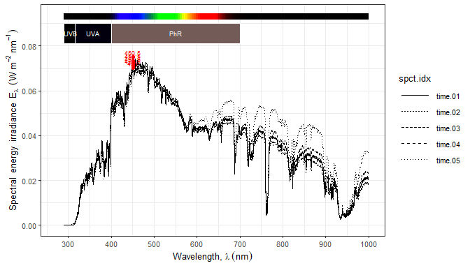

```r
autoplot(sun_evening.mspct)
```

We can choose a different name for the factor identifying the spectra in the collection.

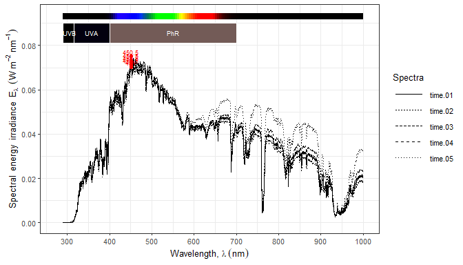

```r
autoplot(sun_evening.mspct, idfactor = "Spectra")
```

With facets, there is only one spectrum per panel. Summaries per waveband are shown.

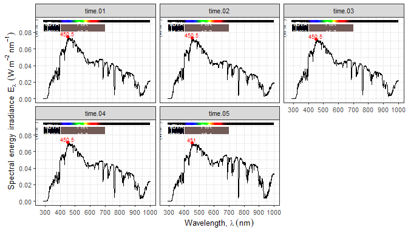

```r
autoplot(sun_evening.spct, facets = TRUE)
```

Above we showed the default faceting by passing `facets = TRUE`. We can set the number of columns by passing a number. For panels in one column we pass `facets = 1`, and for two columns we pass `facets = 2`, and so on.

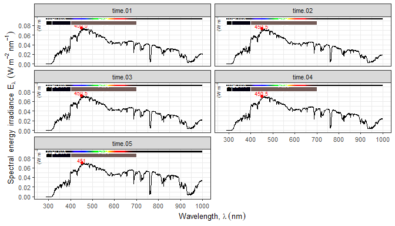

```r
autoplot(sun_evening.mspct, facets = 2)
```

Contrary to `"gg"` objects created with package ‘ggplot2’, the data embedded in the `"gg"` objects created with these `autoplot()` methods retains the attributes used by package ‘photobiology’, including the class.

```r
p1 <- autoplot(sun.spct)
summary(p1$data)
```

```
## Summary of source_spct [522 x 2] object: anonymous
## Wavelength range 280-800 nm, step 0.9230769-1 nm
## Label:  sunlight, simulated
## Measured on  2010-06-22 09:51:00  UTC
## Measured at 60.20911 N, 24.96474 E; Kumpula, Helsinki, FI
## Variables:
##  w.length: Wavelength [nm]
##  s.e.irrad: Spectral energy irradiance [W m-2 nm-1]
## --
##     w.length       s.e.irrad
##  Min.   :280.0   Min.   :0.0000
##  1st Qu.:409.2   1st Qu.:0.4115
##  Median :539.5   Median :0.5799
##  Mean   :539.5   Mean   :0.5160
##  3rd Qu.:669.8   3rd Qu.:0.6664
##  Max.   :800.0   Max.   :0.8205
```

This makes it possible to trace the origin of the data, and also to apply specialised methods to them.

### Wavelengths

We can zoom into the spectrum, by providing a wavelength range in nanometres. Here we pass a vector of two numbers as argument, but any object for which a `range()` method is available can also be used, including longer numeric vectors, objects of one the spectrum classes, such as class `source_spct`, or a `waveband` definition.

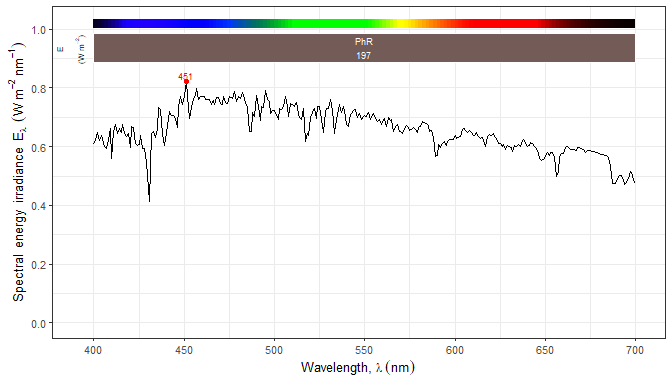

```r
autoplot(sun.spct, range = c(400, 700))
```

We can show summaries for different wavebands, by passing them to parameter `w.band`. We can pass either individual wavebands or lists of wavebands. First a list of wavebands created with a constructor, here showing the limits based on the ISO standard.

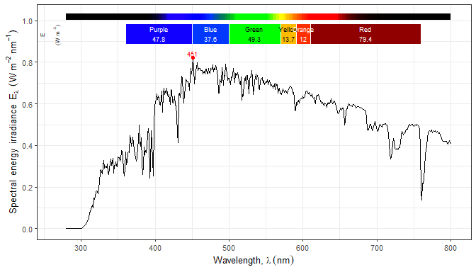

```r
autoplot(sun.spct, w.band = photobiologyWavebands::VIS_bands("ISO"))
```

A single waveband can also be created with a generic constructor.

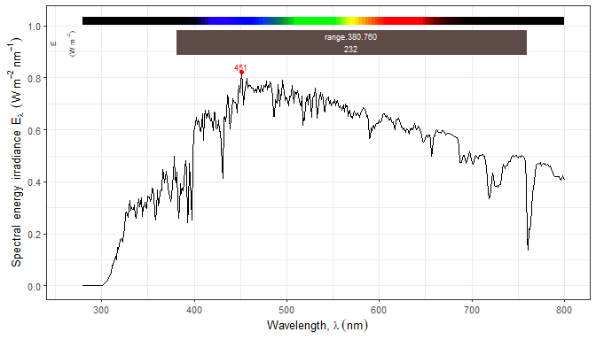

```r
autoplot(sun.spct, w.band = waveband(c(380, 760)))
```

`NULL` as argument for `w.band` is replaced by a waveband covering the full range of the spectral data. The *whole range* is the range plotted, which is controlled by the argument passed to `range`.

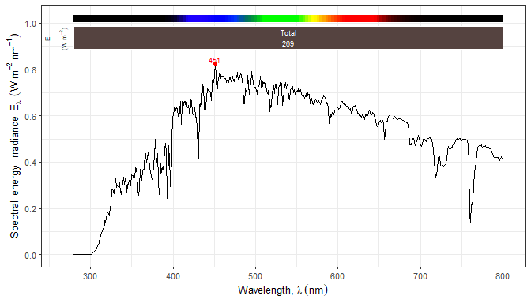

```r
autoplot(sun.spct, w.band = NULL)
```

Summarizing the examples above, arguments passed to `range` and `w.band` play very different roles. Parameter `range`, gives the wavelengths to include in the plot, and the default for `range` is always the range of wavelengths in the spectrum being plotted. The argument to `w.band` is only used for the *annotations* and decorations, described in a later section in more detail.

The effect of `range` is slightly different to the effect of `ggplot2::xlim()` as `range` is used to *trim* the spectral data **before** passing it to `ggplot`, using interpolation when needed (see `photobiology::trim_wl()`). In contrast `xlim` discards data for all wavelengths not within the range.

The default argument to parameter `w.band` can be changed by setting the R option `"photobiology.plot.bands"` to a single waveband object or to a list waveband objects.

Function `set_w.band_default()` allows to set this option using the same syntax as described for parameter `w.band`. See package ‘photobiologyWavebands’ for waveband constructors for ISO and other waveband definitions in common use, and package ‘photobiology’ for defining your own.

```r
set_w.band_default(w.band = Plant_bands())
```

### “Parallel” summaries

All plotting of multiple spectra shown above were done with the default `plot.data = "as.is"`. We can also plot a row-wise summary (wavelength by wavelength, or *parallel* summaries) of the spectra in the collection, here the `mean` of the spectra. Currently implemented only for spectra with identical wavelength vectors and of the same class.

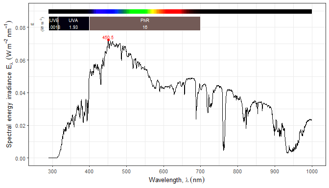

```r
autoplot(sun_evening.mspct, plot.data = "mean")
```

### Summary quantities by waveband

Although the defaults result in the addition of frequently useful annotations, the `autoplot()` methods accepts arguments for several parameters that make possible flexible control of the annotations. Currently, numerical summaries can be added automatically to plots only when a single spectrum is plotted per plot panel.

In this first example we pass `"mean"` as argument to `label.qty`, to print means instead of integrals in the labels. Note that the units and quantity labels for the waveband summaries have also changed.

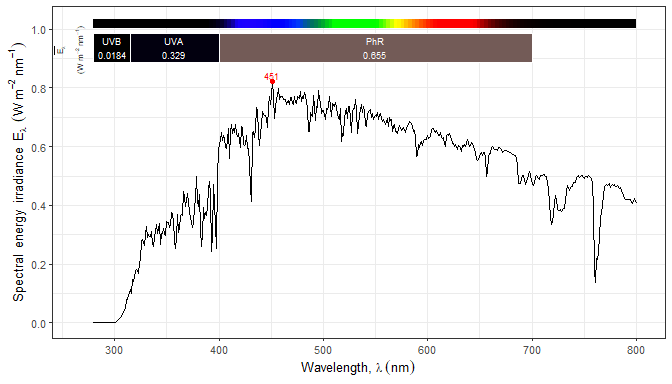

```r
autoplot(sun.spct, label.qty = "mean")
```

Two `label.qty` values need explanation. The first one, `"relative"` displays in labels the relative contribution of the integral of each waveband, to the sum of the integrals of all wavebands displayed in the plot. The second one, `"contribution"` displays in labels the integral of each waveband divided by the integral of the whole spectrum displayed in the plot. Consequently, this second option should be interpreted with caution, as the spectral data is unlikely in many cases to include the whole emission or absorption spectrum of a source. Adding `.pc` to the arguments, that is, using `"relative.pc"` or `"contribution.pc"`, results in the corresponding values being displayed as percentages.

When using `"contribution.pc"` unless the summarized wavebands cover the whole range of wavelengths in the spectrum, the sum of the summary values is less than 100.

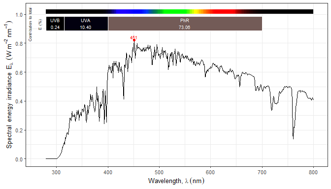

```r
autoplot(sun.spct, label.qty = "contribution.pc")
```

When using `"relative.pc"` the sum adds to 100.

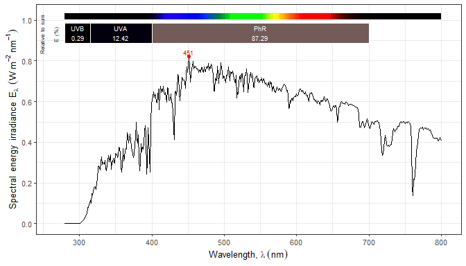

```r
autoplot(sun.spct, label.qty = "relative.pc")
```

### Automatic annotations

Which *annotations* are included can be controlled through parameter `annotations`. It accepts a `character` vector, or a list of `character` vectors as argument. Three values have special meaning if at the head of the vector (with index = 1): `"="` means override the current defaults with the annotations that follow in the vector, `"+"` means add to the current default the annotations that follow, and `"-"` means remove from the current default the annotations that follow. A `NULL` value means use package-defined defaults as is, `""` means no annotations, and `"reserve.space"` means no annotations, but expand axis limits and set identity scales ready for manually adding annotations. Used together with `"-"`, `"title*"`, `"peaks*"` and `"valleys*"` are *wildcards* that remove all flavours of each of these annotations. In cases when the intention is to both add and remove annotations from the default, the argument to parameter `annotations` can be a list of character vectors, which are interpreted as above but operated upon sequentially.

Which annotations are included by default can be changed by setting R option `"photobiology.plot.annotations"` to a character vector with the names of the desired default annotations. Function `set_annotations_default()` allows to set or modify this option using the same syntax as described for parameter `annotations`.

| annotation | default for classes | overrides |
| --- | --- | --- |
| “boxes” | all | “segments” |
| “segments” | none | “boxes” |
| “color.guide” | all |  |
| “peaks” | all | “peak.labels” |
| “peak.labels” | none | “peaks” |
| “valleys” | none | “valley.labels” |
| “valley.labels” | none | “valleys” |
| “wls” | none | “wls.labels” |
| “wls.labels” | none | “wls” |
| “labels” | all |  |
| “summaries” | `source_spct`, `response_spct`, `filter_spct`, `reflector_spct` |  |
| “boundaries” | `raw_spct` |  |
| “title” | none |  |
| “title:*type*” | none |  |
| “title:*type*:*type*” | none |  |
| “title:*type*:*type*:*type*” | none |  |

Titles come in different flavours. Package ‘ggplot2’ supports titles, subtitles and captions. The `"title"` as argument to parameter `annotation` of `autoplot()` methods and of function `autotitle()` takes up to three optional modifiers separated by colons that can be used to specify the contents of the *automatic* title, subtitle and caption. Currently supported modifiers are shown in the table below. If the metadata item is not stored in the spectral object, the title or subtitle will show `NA`. See the documentation of packages ‘photobiology’ and ‘ooacquire’ for information on how to set and unset attributes of spectral objects. To add an arbitrary title and/or subtitle to a plot, use either function `ggtitle()` or function `labs()` from package ‘ggplot2’.

| Modifier | text source used |
| --- | --- |
| `objt` | name of the object plotted |
| `class` | class of the plotted object |
| `what` | what.measured attribute |
| `when` | when.measured attribute |
| `where` | where.measured attribute |
| `how` | how.measured attribute |
| `inst.name` | spectrometer name |
| `inst.sn` | spectrometer serial number |
| `comment` | comment attribute |
| `none` | *no title*, *no subtitle* or *no caption* |

For example `"title:objt"`, the default for `"title"`, adds a title with the name of the object being plotted. `what`, `when`, `where` and `how` use the `what.measured`, `when.measured`, `where.measured` and `how.measured` attributes if available. For example `"title:what:when"` will use the `what.measured` attribute for the title and the `when.measured` attribute for the subtitle.

We add a title, subtitle and caption.

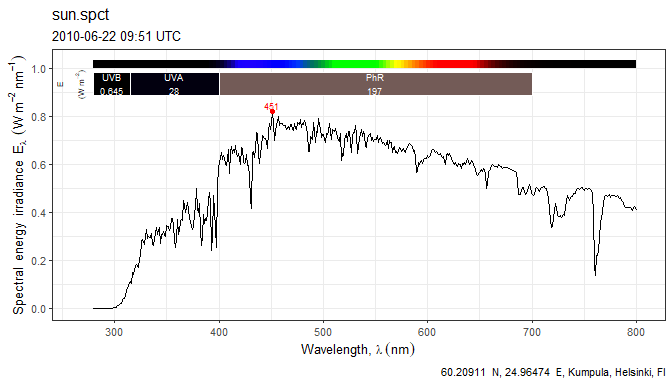

```r
autoplot(sun.spct,
     annotations = c("+", "title:objt:when:where"))
```

We use “none” as a *filler* so that only subtitle and caption are added to the plot.

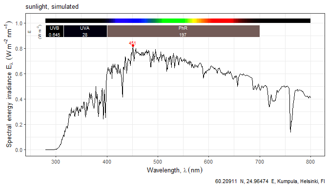

```r
autoplot(sun.spct,
     annotations = c("+", "title:none:what:where"))
```

With `"boundaries"`, we add one or two horizontal dashed lines showing the valid range of values. It does not override any other annotation. (The boundary line is shown in red when a plot displays out-of-range spectral data.)

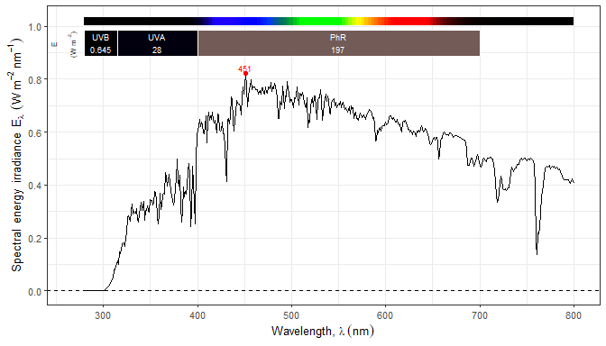

```r
autoplot(sun.spct,
     annotations = c("+", "boundaries"))
```

We can list all the annotations to be included in a plot, in which case `"="` is optional so as to maintain compatibility with earlier versions.

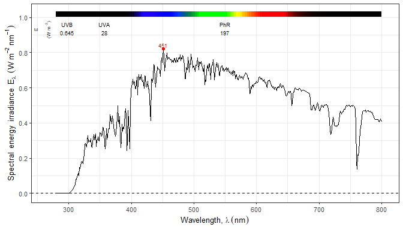

```r
autoplot(sun.spct,
     annotations = c("=", "labels", "summaries", "color.guide", "peaks", "boundaries"))
```

As indicated in the table above, some annotations override other annotations which fulfil a similar role. Here `"segments"` overrides the `"boxes"`, included in the default annotations.

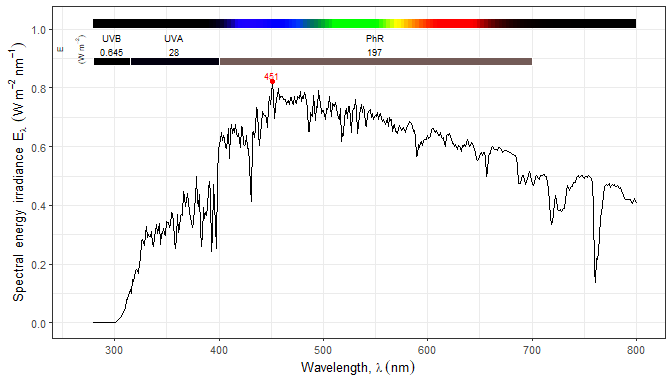

```r
autoplot(sun.spct,
     annotations = c("+", "segments"))
```

We can also *remove* some of the default annotations on a case by case basis.

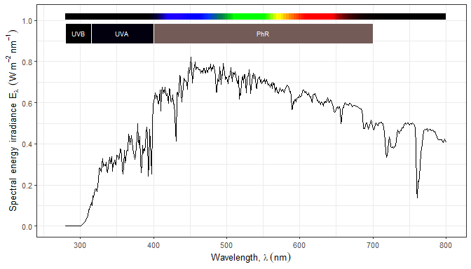

```r
autoplot(sun.spct, annotations = c("-", "summaries", "peaks"))
```

The behaviour of some annotations can be tweaked. Below we add `"valleys"` as annotations, and control with `span` how close to each other are the peaks and valleys found.

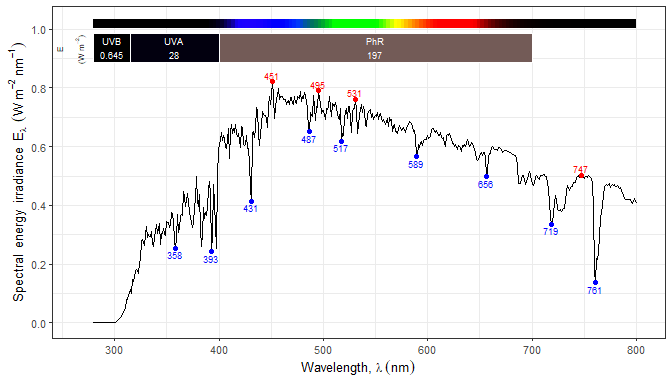

```r
autoplot(sun.spct, annotations = c("+", "valleys"), span = 41)
```

The annotations `"peak.labels"` and `"valley.labels"` override `"peaks"` and `"valleys"`. They use the *repulsive* geometry `geom_label_repel` from package ‘ggrepel’.

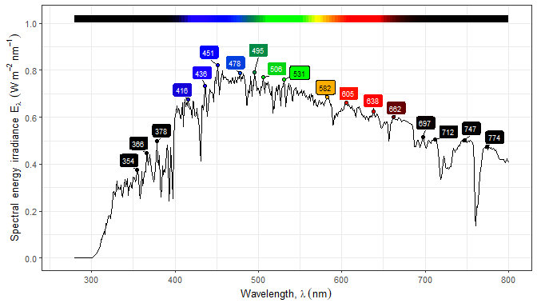

```r
autoplot(sun.spct,
         annotations = list(c("+", "peak.labels"),
                            c("-", "boxes", "summaries", "labels")),
         span = 21)
```

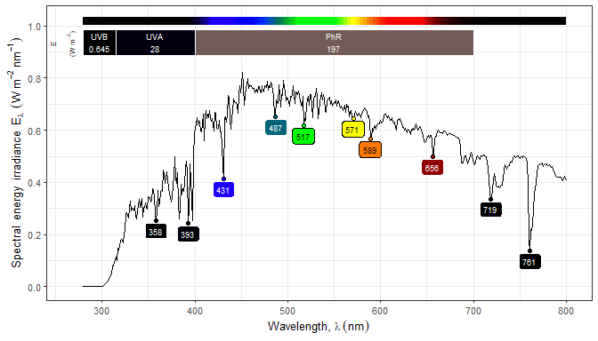

```r
autoplot(sun.spct,
         annotations = list(c("+", "valley.labels"),
                            c("-", "peaks")),
         span = 31)
```

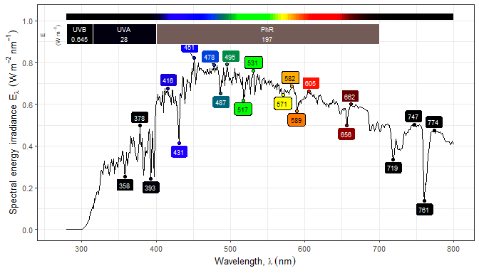

```r
autoplot(sun.spct, annotations = c("+", "peak.labels", "valley.labels"), span = 31)
```

Passing `""` as argument to `annotations` results in a plot with no annotations, and no extra expansion of scale limits.

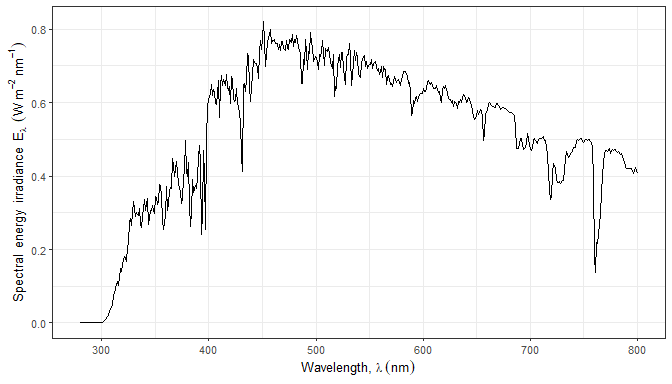

```r
autoplot(sun.spct, annotations = "")
```

Passing `"reserve.space"` as argument to `annotations` results in a plot with no annotations, but with scale limits expanded so as to receive annotations.

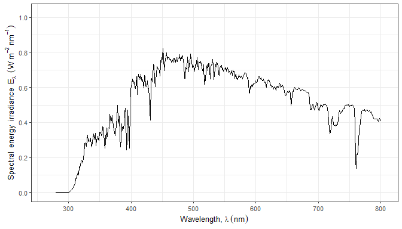

```r
autoplot(sun.spct, annotations = "reserve.space")
```

The size of the font used for the annotations is controlled by argument `text.size`.

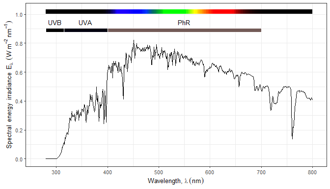

```r
autoplot(sun.spct, annotations = c("=", "segments", "labels", "color.guide"),
     text.size = 3.5)
```

Argument `ylim` allows to manually set the limits of the $y$ axis using the same syntax as in package ‘ggplot2’. The annotations are still automatically positioned, and the range extended to make space for them. In other words the values passed to `ylim` still give the “space” available for plotting data.

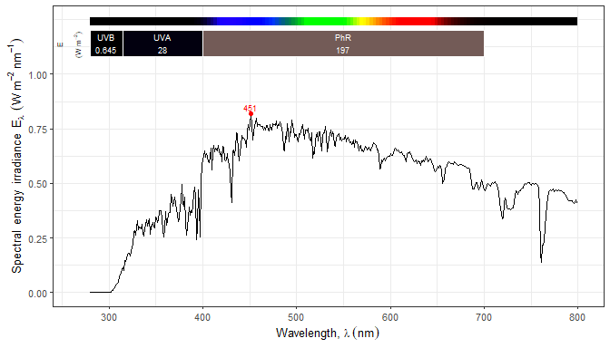

```r
autoplot(sun.spct, ylim = c(NA, 1))
```

The time base of the spectral unit or the duration of the exposure is stored as metadata. As demonstrated here using spectral data integrated over 24 h, a one-day-long exposure, the units in the axis labels change according to the value stored in the metadata.

```r
getTimeUnit(sun.daily.spct)
```

```
## [1] "day"
```